# Basic inferential data analysis - Project Stats-Inf

Jean-Paul Courneya

9/5/2017

# Part 2: Basic inferential data analysis.

```r
library(knitr)
library(ggplot2)
opts_chunk$set(tidy.opts=list(width.cutoff=60),tidy=TRUE)
```

#### Load the ToothGrowth data and perform some basic exploratory data analyses

```r
data("ToothGrowth")
str(ToothGrowth)
```

```
## 'data.frame':    60 obs. of  3 variables:
##  $ len : num  4.2 11.5 7.3 5.8 6.4 10 11.2 11.2 5.2 7 ...
##  $ supp: Factor w/ 2 levels "OJ","VC": 2 2 2 2 2 2 2 2 2 2 ...
##  $ dose: num  0.5 0.5 0.5 0.5 0.5 0.5 0.5 0.5 0.5 0.5 ...
```

The data for the dose is currently numeric. Since the doses are factors they will be changed to factors.

```r
ToothGrowth$dose <- as.factor(ToothGrowth$dose)
str(ToothGrowth)
```

```
## 'data.frame':    60 obs. of  3 variables:
##  $ len : num  4.2 11.5 7.3 5.8 6.4 10 11.2 11.2 5.2 7 ...
##  $ supp: Factor w/ 2 levels "OJ","VC": 2 2 2 2 2 2 2 2 2 2 ...
##  $ dose: Factor w/ 3 levels "0.5","1","2": 1 1 1 1 1 1 1 1 1 1 ...
```

#### What does the Tooth Growth data look like?

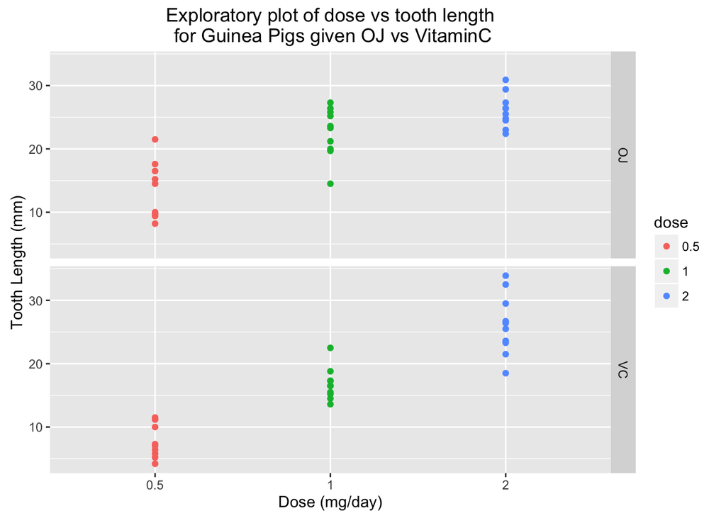

```r
qplot(dose, len, data = ToothGrowth, facets = supp ~ ., color = dose,
    xlab = "Dose (mg/day)", ylab = "Tooth Length (mm)", main = "Exploratory plot of dose vs tooth length\n for Guinea Pigs given OJ vs VitaminC")
```

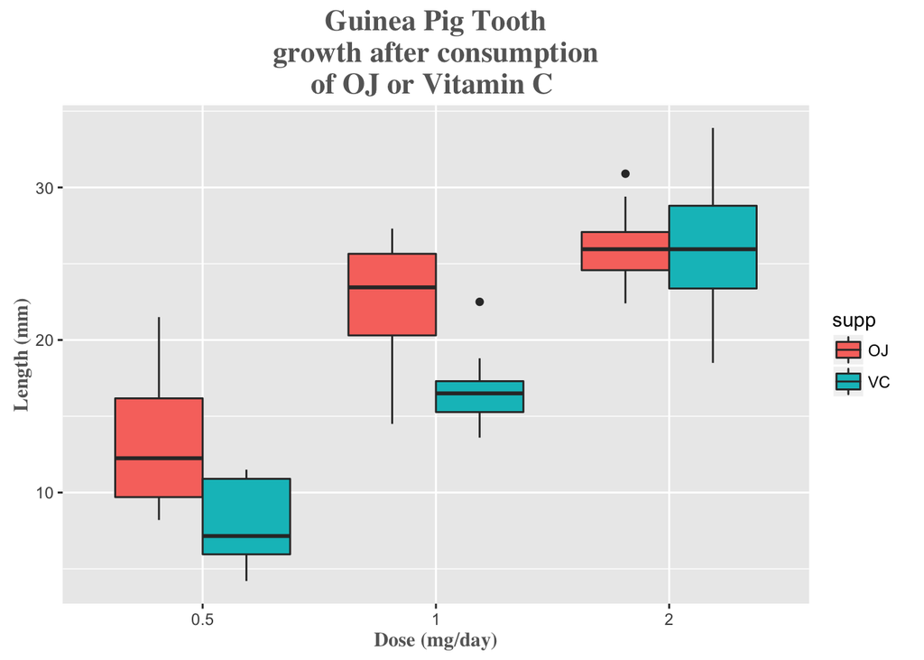

```r
f <- ggplot(ToothGrowth, aes(x = dose, y = len, fill = supp))
f + geom_boxplot() + ggtitle("Guinea Pig Tooth\ngrowth after consumption\nof OJ or Vitamin C ") +
    labs(x = "Dose (mg/day)", y = "Length (mm)") + theme(plot.title = element_text(family = "serif",
    color = "#666666", face = "bold", size = 16, hjust = 0.5)) +
    theme(axis.title = element_text(family = "serif", color = "#666666",
        face = "bold", size = 11))
```

### A basic summary of the data

```r
summary(ToothGrowth)
```

```
##       len        supp     dose
##  Min.   : 4.20   OJ:30   0.5:20
##  1st Qu.:13.07   VC:30   1  :20
##  Median :19.25           2  :20
##  Mean   :18.81
##  3rd Qu.:25.27
##  Max.   :33.90
```

# Compare tooth growth by supp and dose using confidence intervals and/or hypothesis tests

#### The overall goal of understanding this data is achieved by determining if vitamin C affects tooth growth and if it matters how the vitamin C is delivered.

#### A t.test can be used to compare the tooth len growth between supplements (VitaminC or OJ) and each dose.

##### Tooth len growth at a dose of 0.5 mg/day (VitaminC or OJ)

Comparison at (p < 0.05)

```r
t.test(ToothGrowth$len[ToothGrowth$supp == "OJ" & ToothGrowth$dose ==
    0.5], ToothGrowth$len[ToothGrowth$supp == "VC" & ToothGrowth$dose ==
    0.5])
```

```
##
##  Welch Two Sample t-test
##
## data:  ToothGrowth$len[ToothGrowth$supp == "OJ" & ToothGrowth$dose ==  and ToothGrowth$len[ToothGrowth$supp == "VC" & ToothGrowth$dose ==     0.5] and     0.5]
## t = 3.1697, df = 14.969, p-value = 0.006359
## alternative hypothesis: true difference in means is not equal to 0
## 95 percent confidence interval:
##  1.719057 8.780943
## sample estimates:
## mean of x mean of y
##     13.23      7.98
```

#### OJ has a higher effect on tooth growth at 0.5 mg/day

##### Tooth len growth at a dose of 1.0 mg/day (VitaminC or OJ)

Comparison at (p < 0.05)

```r
t.test(ToothGrowth$len[ToothGrowth$supp == "OJ" & ToothGrowth$dose ==
    1], ToothGrowth$len[ToothGrowth$supp == "VC" & ToothGrowth$dose ==
    1])
```

```
##
##  Welch Two Sample t-test
##
## data:  ToothGrowth$len[ToothGrowth$supp == "OJ" & ToothGrowth$dose ==  and ToothGrowth$len[ToothGrowth$supp == "VC" & ToothGrowth$dose ==     1] and     1]
## t = 4.0328, df = 15.358, p-value = 0.001038
## alternative hypothesis: true difference in means is not equal to 0
## 95 percent confidence interval:
##  2.802148 9.057852
## sample estimates:
## mean of x mean of y
##     22.70     16.77
```

#### OJ has a higher effect on tooth growth at 1.0 mg/day

##### Tooth len growth at a dose of 2.0 mg/day (VitaminC or OJ)

Comparison at (p < 0.05)

```r
t.test(ToothGrowth$len[ToothGrowth$supp == "OJ" & ToothGrowth$dose ==
    2], ToothGrowth$len[ToothGrowth$supp == "VC" & ToothGrowth$dose ==
    2])
```

```
##
##  Welch Two Sample t-test
##
## data:  ToothGrowth$len[ToothGrowth$supp == "OJ" & ToothGrowth$dose ==  and ToothGrowth$len[ToothGrowth$supp == "VC" & ToothGrowth$dose ==     2] and     2]
## t = -0.046136, df = 14.04, p-value = 0.9639
## alternative hypothesis: true difference in means is not equal to 0
## 95 percent confidence interval:
##  -3.79807  3.63807
## sample estimates:
## mean of x mean of y
##     26.06     26.14
```

#### There is no difference between OJ and VitaminC on tooth growth at 2.0 mg/day

#### Ive just demonstrated that there is a difference in tooth growth between supplements. at the low doses (0.5 mg/day, 1.0 mg/day) OJ has more of an effect on Tooth growth but not at 2.0 mg/day

#### Next I will compare tooth growth based on dose of supplement (OJ or VC).

##### First I will compare 0.5 mg/day vs 1 of OJ

Comparison at (p < 0.05).

```r
t.test(ToothGrowth$len[ToothGrowth$supp == "OJ" & ToothGrowth$dose ==
    0.5], ToothGrowth$len[ToothGrowth$supp == "OJ" & ToothGrowth$dose ==
    1])
```

```
##
##  Welch Two Sample t-test
##
## data:  ToothGrowth$len[ToothGrowth$supp == "OJ" & ToothGrowth$dose ==  and ToothGrowth$len[ToothGrowth$supp == "OJ" & ToothGrowth$dose ==     0.5] and     1]
## t = -5.0486, df = 17.698, p-value = 8.785e-05
## alternative hypothesis: true difference in means is not equal to 0
## 95 percent confidence interval:
##  -13.415634  -5.524366
## sample estimates:
## mean of x mean of y
##     13.23     22.70
```

There is a significant difference.

##### Here is the comparison 0.5 mg/day vs 2 of OJ

Comparison at (p < 0.05).

```r
t.test(ToothGrowth$len[ToothGrowth$supp == "OJ" & ToothGrowth$dose ==
    0.5], ToothGrowth$len[ToothGrowth$supp == "OJ" & ToothGrowth$dose ==
    2])
```

```
##
##  Welch Two Sample t-test
##
## data:  ToothGrowth$len[ToothGrowth$supp == "OJ" & ToothGrowth$dose ==  and ToothGrowth$len[ToothGrowth$supp == "OJ" & ToothGrowth$dose ==     0.5] and     2]
## t = -7.817, df = 14.668, p-value = 1.324e-06
## alternative hypothesis: true difference in means is not equal to 0
## 95 percent confidence interval:
##  -16.335241  -9.324759
## sample estimates:
## mean of x mean of y
##     13.23     26.06
```

There is a significant difference

##### Here is the comparison 1.0 mg/day vs 2 of OJ

Comparison at (p < 0.05).

```r
t.test(ToothGrowth$len[ToothGrowth$supp == "OJ" & ToothGrowth$dose ==
    1], ToothGrowth$len[ToothGrowth$supp == "OJ" & ToothGrowth$dose ==
    2])
```

```
##
##  Welch Two Sample t-test
##
## data:  ToothGrowth$len[ToothGrowth$supp == "OJ" & ToothGrowth$dose ==  and ToothGrowth$len[ToothGrowth$supp == "OJ" & ToothGrowth$dose ==     1] and     2]
## t = -2.2478, df = 15.842, p-value = 0.0392
## alternative hypothesis: true difference in means is not equal to 0
## 95 percent confidence interval:
##  -6.5314425 -0.1885575
## sample estimates:
## mean of x mean of y
##     22.70     26.06
```

The difference is significant but not the same maginitude of effect as between 0.5 mg/day and (1 or 2)

#### Next I will compare the effect of Vitamin C

##### First I will compare 0.5 mg/day vs 1 of VC

Comparison at (p < 0.05).

```r
t.test(ToothGrowth$len[ToothGrowth$supp == "VC" & ToothGrowth$dose ==
    0.5], ToothGrowth$len[ToothGrowth$supp == "VC" & ToothGrowth$dose ==
    1])
```

```
##
##  Welch Two Sample t-test
##
## data:  ToothGrowth$len[ToothGrowth$supp == "VC" & ToothGrowth$dose ==  and ToothGrowth$len[ToothGrowth$supp == "VC" & ToothGrowth$dose ==     0.5] and     1]
## t = -7.4634, df = 17.862, p-value = 6.811e-07
## alternative hypothesis: true difference in means is not equal to 0
## 95 percent confidence interval:
##  -11.265712  -6.314288
## sample estimates:
## mean of x mean of y
##      7.98     16.77
```

There is a significant difference.

##### Here is the comparison 0.5 mg/day vs 2 of VC

Comparison at (p < 0.05).

```r
t.test(ToothGrowth$len[ToothGrowth$supp == "VC" & ToothGrowth$dose ==
    0.5], ToothGrowth$len[ToothGrowth$supp == "VC" & ToothGrowth$dose ==
    2])
```

```
##
##  Welch Two Sample t-test
##
## data:  ToothGrowth$len[ToothGrowth$supp == "VC" & ToothGrowth$dose ==  and ToothGrowth$len[ToothGrowth$supp == "VC" & ToothGrowth$dose ==     0.5] and     2]
## t = -10.388, df = 14.327, p-value = 4.682e-08
## alternative hypothesis: true difference in means is not equal to 0
## 95 percent confidence interval:
##  -21.90151 -14.41849
## sample estimates:
## mean of x mean of y
##      7.98     26.14
```

There is a significant difference

##### Here is the comparison 1.0 mg/day vs 2 of VC

Comparison at (p < 0.05).

```r
t.test(ToothGrowth$len[ToothGrowth$supp == "VC" & ToothGrowth$dose ==
    1], ToothGrowth$len[ToothGrowth$supp == "VC" & ToothGrowth$dose ==
    2])
```

```
##
##  Welch Two Sample t-test
##
## data:  ToothGrowth$len[ToothGrowth$supp == "VC" & ToothGrowth$dose ==  and ToothGrowth$len[ToothGrowth$supp == "VC" & ToothGrowth$dose ==     1] and     2]
## t = -5.4698, df = 13.6, p-value = 9.156e-05
## alternative hypothesis: true difference in means is not equal to 0
## 95 percent confidence interval:
##  -13.054267  -5.685733
## sample estimates:
## mean of x mean of y
##     16.77     26.14
```

Overall Guinea Pig tooth growth is most affected by OJ supplement.There is a noticible effect between doses of Vitamin C however within doses.